# Search

Jan 1, 0001

# Visualisation and Dimension Reduction

Christophe Ambroise

christophe.ambroise@univ-evry.fr

UEVE, UMR CNRS 8071

February 20, 2025

# Evaluation

A Natural Language Processing (NLP) project to be completed in pairs:

```
-   Code (in a Python notebook or R Markdown)
-   Presentation (scheduled for April 4, 2025)
```

# Factor Analyser

## Factor Analysis

- Using discrete latent variables provides limited summary (clustering)
- An alternative is to use a vector of real-valued latent variables, $\boldsymbol z \in \mathbb R^L$.
- “Factor analysis (FA) is a statistical method used to describe variability among observed, correlated variables in terms of a potentially lower number of unobserved variables called factors.” Wikipedia quote.
- PCA and FA are related, but not identical.

## The model of factor analysis

We consider the observation $\boldsymbol x \in \mathbb R^D$
$$\boldsymbol x = \boldsymbol W \boldsymbol z + \boldsymbol \mu + \epsilon$$
where

- the noise $\epsilon \sim \mathcal N_D (\boldsymbol 0, \boldsymbol \Psi)$
- the hidden (latent) vector $\boldsymbol z \sim \mathcal N_L (\boldsymbol 0, \boldsymbol I_L)$

$$p(\boldsymbol x | \boldsymbol z, \theta) = \mathcal N (\boldsymbol W \boldsymbol z + \boldsymbol \mu, \boldsymbol \Psi)$$
the mean is a linear function of the (hidden) inputs

- $\boldsymbol W$ is a $D\times L$ matrix, known as the factor loading matrix,
- $\boldsymbol \Psi$ is a $D\times D$ covariance matrix that we take to be diagonal

The special case in which $\boldsymbol \Psi=\sigma^2 I$ is called probabilistic principal components analysis or PPCA.

## Reminder: Joint and conditional Gaussian distribution (see Murphy chapter 4)

Let us recall that if

- $\boldsymbol z \sim \mathcal N(\boldsymbol \mu_z, \boldsymbol \Sigma_{zz})$ and $\boldsymbol x \sim \mathcal N(\boldsymbol \mu_x, \boldsymbol \Sigma_{xx})$ and $cov(\boldsymbol z,\boldsymbol x)=\boldsymbol \Sigma_{zx}$

then

$$p(\boldsymbol z, \boldsymbol x) = N (\begin{bmatrix} \boldsymbol z\\ \boldsymbol x \end{bmatrix} | \begin{bmatrix} \boldsymbol \mu_z\\ \boldsymbol \mu_x \end{bmatrix}, \begin{bmatrix} \boldsymbol \Sigma_{zz} & \boldsymbol \Sigma_{zx} \\ \boldsymbol \Sigma_{xz} & \boldsymbol \Sigma_{zz} \end{bmatrix})$$

and

$$p(\boldsymbol z, \boldsymbol x) = p(\boldsymbol z | \boldsymbol x)p(\boldsymbol x) =
\mathcal N (\boldsymbol z |\boldsymbol \mu_{z|x}, \boldsymbol \Sigma_{z|x}) \mathcal N (\boldsymbol x| \boldsymbol \mu_x, \boldsymbol \Sigma_{xx})$$
where

- $\boldsymbol \mu_{z|x} = \boldsymbol \mu_z + \boldsymbol \Sigma_{zx} \boldsymbol \Sigma_{xx}^{-1}(\boldsymbol x-\boldsymbol \mu_x )$
- $\boldsymbol \Sigma_{z|x} = \boldsymbol \Sigma_{zz} - \boldsymbol \Sigma_{zx}\boldsymbol \Sigma_{xx}^{-1}\boldsymbol \Sigma_{xz}$

## Marginal and posterior distribution

### Marginal distribution

$$\boldsymbol x \sim \mathcal N_D (\boldsymbol \mu , \boldsymbol{\Sigma_{xx}=WW^T+ \Psi})$$

### Posterior distribution

$$\boldsymbol z | \boldsymbol x \sim \mathcal N_L (\boldsymbol \mu_{z|x} , \boldsymbol \Sigma_{z|x})$$
where

- $\boldsymbol \Sigma_{z|x} = \boldsymbol{(I_L + W^T \Psi^{-1} W)^{-1}}=S$
- $\boldsymbol \mu_{z|x} = \boldsymbol {\Sigma_{z|x}\Sigma_{xx}^{-1}} (\boldsymbol x -\boldsymbol \mu)=\boldsymbol{SW^T \Psi^{-1}}(\boldsymbol x -\boldsymbol \mu)$

### Exercice

Demonstrate the above formulas

## Estimation

### The mean $\boldsymbol \mu$

can be estimated by maximum likelihood
$$\boldsymbol \mu_{mle} = \bar{\boldsymbol x}$$

### $\boldsymbol W$ and $\boldsymbol \Psi$

are estimated using an EM algorithm

## EM algorithm

### Data

- Observed data $\boldsymbol: x_{1:n}$
- Missing (or hidden) data : $\boldsymbol: z_{1:n}$

### Principle

- Starting from $\theta^0$
- At step $q$
  - E(xpectation) step: $Q(\theta,\theta^q) = E_{Z_{1:n} | \boldsymbol x_{1:n}}[\log P( \boldsymbol x_{1:n},\boldsymbol z_{1:n},\theta)]$
  - M(aximisation) step: $\theta^{q+1} = argmax_\theta Q(\theta,\theta^q)$

## EM for factor analysis

Let us assume that $\boldsymbol \mu=0$ (centering of the $\boldsymbol x_i$), the complete log-likelihood is

$$\begin{eqnarray*}
\log{p( \boldsymbol {X,Z|\mu,W,\Psi})} &=& \sum_i \log \mathcal N_L(z_i; \boldsymbol 0,\boldsymbol I) + \log \mathcal N_D(x_i; \boldsymbol {Wz_i},\boldsymbol \Psi) \\
&=& -\frac{n}{2} \log |\boldsymbol I_L | -\frac{n}{2} Tr(\boldsymbol{\hat{\Sigma}_{zz}}) \\
& & -\frac{n}{2} \log |\boldsymbol \Psi | -\frac{n}{2} Tr(\boldsymbol{\hat{\Sigma}_{xx}\Psi^{-1}}) + Cst
\end{eqnarray*}$$
where
$$\boldsymbol{\hat{\Sigma}_{xx}}=\frac{1}{n}\sum_i (\boldsymbol x_i - \boldsymbol{Wz_i})(\boldsymbol x_i - \boldsymbol{Wz_i})^T$$

### Exercice

Demonstrate the above formula

## E step

The expectation of the complete log-likelihood requires

1. $\mathbb E_{z|x}[\boldsymbol z_i]= \boldsymbol{SW^T \Psi^{-1}}(\boldsymbol x_i -\boldsymbol \mu)$ where $\boldsymbol S = \boldsymbol{(I_L + W^T \Psi^{-1} W)^{-1}}$
2. $\mathbb E_{z|x}[\boldsymbol{z_i z_i^T}] = E_{z|x}[\boldsymbol z_i]E_{z|x}[\boldsymbol z_i^T] + \boldsymbol S$

## M step

Reminders

$$\frac{\partial (b^Ta)}{\partial a}=b$$
$$\frac{\partial (a^TAa)}{\partial a}=(A+A^ T)a$$
$$\frac{\partial}{\partial A}tr(BA)=B^T$$
$$\frac{\partial}{\partial A}\log |A|=(A^{-1})^T$$
$$tr(ABC)=tr(CAB)=tra(BCA)$$
Thus if $x$ is a vector
$$x^T A x = tr(x^TAx)=tr(Axx^T)$$

## M step for $\boldsymbol \Psi$

$$\mathbb E_{z|x} \left[ \frac{\partial L({\boldsymbol W, \boldsymbol \Psi)}}{\partial{\boldsymbol \Psi^{-1}}}\right] = \mathbb E_{z|x} \left[ \frac{n}{2}(\boldsymbol \Psi - \boldsymbol{\hat{\Sigma}_{xx}})\right] = \frac{n}{2}(\boldsymbol \Psi - \mathbb E_{z|x} \left[\boldsymbol{\hat{\Sigma}_{xx}}\right])=0$$

where
$$\begin{eqnarray*}
\mathbb E_{z|x} \left[\boldsymbol{\hat{\Sigma}_{xx}}\right] &= &\frac{1}{n}{\Large(} \sum_i \boldsymbol{x_i x_i^T} + W(\sum_i \mathbb E_{z|x} \left[\boldsymbol{z_i z_i^T}\right])W^T -2W\sum_i \boldsymbol{E_{z|x} \left[z_i\right] x_i^T}{\Large)}\\
&= &\frac{1}{n}{\Large(} \sum_i \boldsymbol{x_i x_i^T} + W(\sum_i \mathbb E_{z|x} \left[\boldsymbol{z_i x_i^T }\right])-2W\sum_i \boldsymbol{E_{z|x} \left[z_i\right] x_i^T}{\Large)}\\
&= &\frac{1}{n}{\Large(} \sum_i \boldsymbol{x_i x_i^T} -W\sum_i \boldsymbol{E_{z|x} \left[z_i\right] x_i^T}{\Large)}
\end{eqnarray*}$$

## M step for $\boldsymbol W$

$$\mathbb E_{z|x} \left[ \frac{\partial L({\boldsymbol W, \boldsymbol \Psi)}}{\partial{\boldsymbol W}}\right] = \mathbb E_{z|x} \left[-\boldsymbol \Psi^{-1}\sum_i x_i z_i^T + \boldsymbol \Psi^{-1} W\sum_i z_i z_i^T \right]=0$$

## M Step summary

### Loading matrix

$$\boldsymbol W^{q+1} = \left(\sum_i (\boldsymbol x_i -\boldsymbol{\bar{x}}) \mathbb E_{z|x}[\boldsymbol z_i]^T\right)\left(\sum_i \mathbb E_{z|x}[\boldsymbol z_i \boldsymbol z_i^T]\right)^{-1}$$

### Noise covariance matrix

$$\boldsymbol \Psi^{q+1} = \frac{1}{N} diag {\huge \{ } \sum_i \boldsymbol{x_i x_i^T} - \boldsymbol W^{q+1} \mathbb E_{z|x}[\boldsymbol z_i] \boldsymbol x_i^T {\huge\}}$$

### Log-likelihood

The log-likelihood can be computed using the EM decomposition

$$\log P(X;\boldsymbol \Theta) = E_{Z_{1:n} | \boldsymbol x_{1:n}}[\log P( \boldsymbol x_{1:n},\boldsymbol z_{1:n};\theta)] - E_{Z_{1:n} | \boldsymbol x_{1:n}}[\log P( \boldsymbol z_{1:n}| \boldsymbol x_{1:n};\theta)]$$

## Implementation of the algorithm

### Initialisation via a PCA

```r
initialisation.FA<-function(X,L=1){
  # Return W and Psi
  d<-ncol(X)
  Sigmaxx<-var(X)
  W<-eigen(Sigmaxx)$vectors[,1:L]
  if (L==1) W<-cbind(W)
  Psi<-rep(1,d)
  return(list(W=W,Psi=Psi))
}
```

### E step

```r
FA.E.step<-function(X,W,Psi){
  # X is assumed to be centered
  # M contain the contionnal expectation of the latent factor
  # S contains the covariance of the latent factor
  L<-ncol(W)
  S <- solve(diag(L) + t(W)%*%diag(1/Psi)%*%W)
  M<- X%*%diag(1/Psi)%*%W%*%S
  return(list(S=S,M=M))
}
```

### M Step

```r
FA.M.step<-function(X,S,M,W,Psi){
  n<-nrow(X)
  Psi<-1/n*diag(t(X)%*%X -W%*%t(M)%*%X)
  W<- (t(X)%*%M)%*%solve(n*S+t(M)%*%M)
  return(list(Psi=Psi,W=W))
}
```

### Computation of the criterion

```r
log.likelihood.FA<-function(X,S,M,Psi,W){
  n<-nrow(X)
  Sigmax<-(t(X)%*%X-W%*%t(M)%*%X)
  return(-(sum(diag(S+t(M)%*%M/n))
          +log(det(diag(Psi)))+
            log(det(S))+
            1/n*sum(diag(Sigmax%*%diag(1/Psi)))))
}
```

### Putting it all together

```r
FA.EM<-function(X,L=1,max.iter=50){
  X<-scale(X,scale=FALSE);mu<-attr(X,"scaled:center")
  log.likelihood<-NULL; init<-initialisation.FA(X,L)
  W<-init$W;  Psi<-init$Psi; criterion<- Inf; iteration<-1;
  log.likelihood[iteration]<--Inf
  while ((criterion>1e-6)&&(iteration<=max.iter)){
    E.step<-FA.E.step(X,W,Psi); E.step$S->S; E.step$M->M
    M.step<-FA.M.step(X,S,M,W,Psi); M.step$Psi->Psi; M.step$W->W
    iteration<-iteration+1
    log.likelihood[iteration]<-log.likelihood.FA(X,S,M,Psi,W)
    criterion<-abs((log.likelihood[iteration] - log.likelihood[iteration-1])/max(log.likelihood[iteration], log.likelihood[iteration-1]))
  }
  return(list( W=data.frame(W), Psi=Psi,
               M=data.frame(M), S=S,mu=mu,
               log.likelihood= log.likelihood[-1]))
}
```

## Example with the Iris

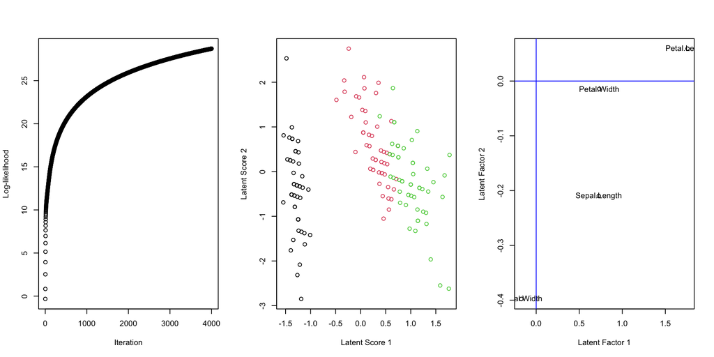

## Unidentifiability

- If we consider $\boldsymbol R$ an orthogonal rotation matrix such that

$$\boldsymbol R \boldsymbol R^T = \boldsymbol I$$

It appears that $\tilde{\boldsymbol W}={\boldsymbol W \boldsymbol R}$ produces the same log-likelihood.

- ${\boldsymbol W}$ cannot be uniquely identified.

## Possible rotations

1. Forcing $\boldsymbol W$ to be orthogonal with colmuns ordered by deacresing variance
2. Forcing $\boldsymbol W$ to be lower triangular (problem of founder variables)
3. Choosing an informative rotation matrix. For example the varimax rotation.
4. …

### Varimax

Varimax rotation maximizes the sum of the variance of the squared correlations between variables and factors

$$R_\mathrm{VARIMAX} = \operatorname{arg}\max_R \left(\frac{1}{p}\sum_{j=1}^k \sum_{i=1}^p (W R)^4_{ij} - \sum_{j=1}^k \left(\frac{1}{p}\sum_{i=1}^p (W R)^2_{ij}\right)^2\right)$$

This results in high factor loadings for a small number of variables and low factor loadings for the rest.

## Varimax

```r
W.FA<-FA.result$W
W.Varimax<-varimax(as.matrix(FA.result$W))$loadings
print(W.Varimax)
```

```
Loadings:
             Latent Factor 1 Latent Factor 2
Sepal.Length  0.756
Sepal.Width                  -0.429
Petal.Length  1.683           0.509
Petal.Width   0.711           0.174

               Latent Factor 1 Latent Factor 2
SS loadings              3.916           0.473
Proportion Var           0.979           0.118
Cumulative Var           0.979           1.097
```

## Mixture of factor analysers

- Factor analyses is a way to estimate a variance matrix with few parameters
- This property can be used in the context of Gaussian mixture model assuming the following parameterization for component densities:
  $$p(\boldsymbol x_i |\boldsymbol z_i, q_i=k) = \mathcal{N}(\boldsymbol x_i | \boldsymbol \mu_k + \boldsymbol W_k \boldsymbol z_i , \boldsymbol \Psi)$$
  where $k$ is the component number and $W_k$ is a loading matrix defining the relation between the observation $\boldsymbol x_i$ and the latent vector $\boldsymbol z_i$
- This approach is simular to the Banfield-Raftery idea of decomposing the component variance matrix $k$ in volume, form et direction.

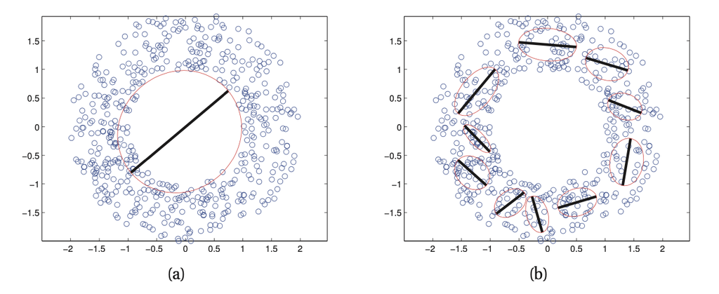

Mixture of 1d PPCAs with 1 and 10 components (from Murphy Chapter 12)

## Relation to principal component analysis

### Assumption

If

- $\boldsymbol \Psi = \sigma^2 \boldsymbol I$
- $\boldsymbol W$ is orthogonal

and

- $\sigma^2 \rightarrow 0$

Then

Tipping, M. and C. Bishop (1999, Probabilistic principal component analysis. J. of Royal Stat. Soc. Series B 21(3), 611–622) showed that FA is equivalent to PCA

### Criterion

$$J(\boldsymbol W,\boldsymbol Z) = \| \boldsymbol X - \boldsymbol Z \boldsymbol W^T\|_F^2$$
where $\boldsymbol W^T \boldsymbol W=\boldsymbol I$

## A Constrained EM Algorithm for PCA (from Ahn, J.-H. and J.-H. Oh, 2003)

```r
upper<-function(A){A[lower.tri(A,diag=FALSE)]<-0;return(A)}
lower<-function(A){A[upper.tri(A,diag=FALSE)]<-0;return(A)}
PCA.EM<-function(X,q=2){
  p<-ncol(X); n<-nrow(X)
  W<-diag(p)[,1:q]; M<-X%*%W # Initialisation
  Jold<-0; J<-1; iteration<-0; Error<-NULL
  while ((abs(J - Jold)>1e-3)){
    Jold<-sum((X-M%*%t(W))^2)
    S <- solve(upper(t(W)%*%W)); M<- X%*%W%*%S # E-step
    W<- (t(X)%*%M)%*%solve(lower(n*S+t(M)%*%M))# M-step
    W<-apply(W,2,function(x){x/sqrt(sum(x^2))})#orthogonalisation
    J<-sum((X-M%*%t(W))^2); Error[iteration<-iteration+1]<-J
  }
  return(list(W=data.frame(W),M=data.frame(M),Error=Error))}
```

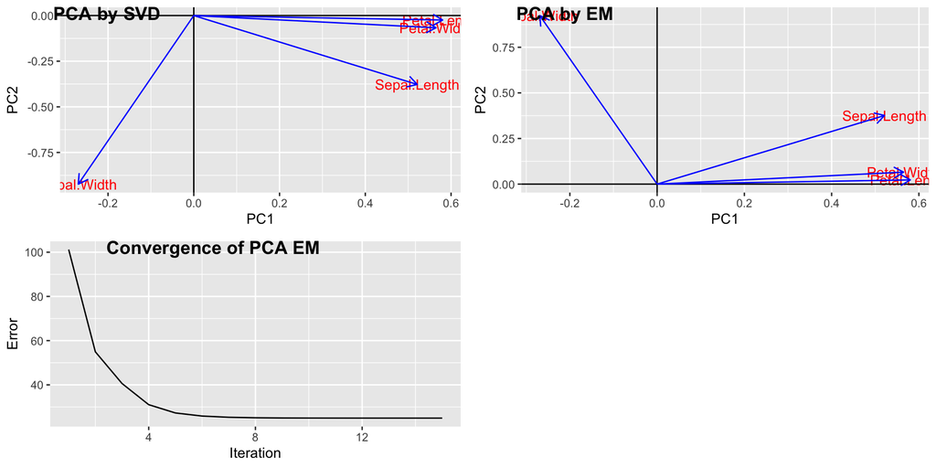

# Independent Component Analysis

## Independent Component analysis (Wikipedia)

Independent component analysis attempts to decompose a multivariate signal into independent non-Gaussian signals.

### Cocktail party problem

Underlying speech signals are separated from a sample data consisting of people talking simultaneously in a room.

That the ICA separation of mixed signals gives very good results is based on two assumptions

### Two assumptions:

- The source signals are independent of each other.
- The values in each source signal have non-Gaussian distributions.

## ICA Historical context (French Wikipedia)

### Blind source separation

The first formulation was carried out in 1984 by Jeanny Hérault and Bernard Ans, two researchers in neuroscience and signal processing, to model in the form of a neuromimetic network self-adaptive encoding and decoding of movement in humans.

### France and Finland

- The French signal processing community adopted a statistical formalism
- While Finnish researchers aimed to extend principal component analysis by means of a connectionist formalism (1985)

### Formalisation

- A first formalism of the blind source separation problem, as well as an algorithm making it possible to obtain a solution, was proposed by C. Jutten and J. Hérault in 1991.
- Mathematical formalization in the simplest case (linear mixing snapshot) was carried out in 1994 by P. Comon

## ICA Model

Let $\boldsymbol x_t \in \mathbb R^D$ be the observed signal at the sensors at ‘’time’’ $t$, and $\boldsymbol z_t \in \mathbb R^L$ be the vector of source signals:

$$\boldsymbol x_t = \boldsymbol W\boldsymbol z_t + \boldsymbol \epsilon_t$$

- $\boldsymbol W$ is an $D\times L$ matrix,
- $\boldsymbol \epsilon_t \sim \mathcal N (0, \boldsymbol \Psi)$.

The model is identical to factor analysis (or PCA if there is no noise, except we don’t in general require orthogonality of W).

However, we will use a **different prior** for $p(\boldsymbol z_t)$.

In FA, we assume each source is independent, and has a Gaussian distribution.

### Relax this Gaussian assumption on latent variables (sources)

$$p(\boldsymbol z_t) = \prod_j p_j(z_{tj}).$$

### Additionnal assumptions

- Without loss of generality the variance of the source distributions is contrained to unity
- W is assumed square and hence invertible.

## Maximum likelihood estimation of ICA

If the data is centered and whitened, we have

$$\mathbb E[\boldsymbol x \boldsymbol x^t]=I=\boldsymbol W \mathbb E[\boldsymbol z \boldsymbol z^T]\boldsymbol W^T =\boldsymbol W \boldsymbol W^T$$
also have

Hence we see that $\boldsymbol W$ must be orthogonal. This reduces the number of parameters we have to estimate from $D^2$ to $D(D - 1)/2$.

### Recognition weights/Generative weights

Let $\boldsymbol V = \boldsymbol W^{-1}$ these are often called the recognition weights, as opposed to $\boldsymbol W$, which are the generative weights

### Log-likelihood

Since $\boldsymbol x = \boldsymbol W \boldsymbol z$, we have

$$p_x(\boldsymbol W \boldsymbol z_t) = p_z(\boldsymbol z_t) |det(\boldsymbol W^{-1})| = p_z(\boldsymbol V \boldsymbol x_t)|det(\boldsymbol V)|$$
Hence assuming T iid samples:
$$L(\boldsymbol V)= \frac{1}{T}\log p(\mathcal D | \boldsymbol V)=\underbrace{\log | det(\boldsymbol V)|}_0+\frac{1}{T}
\sum_{jt} \log p_j(v_j^T \boldsymbol x_t)$$
since $\boldsymbol V$ is orthogonal.

## Estimation via Gradient Ascent

Let us define $h_j = \boldsymbol v_j^T \boldsymbol x$,

$$g_j(h_j) = \frac{\partial \log p_j(h_j)}{\partial h_j},$$
$$\frac{\partial L(\boldsymbol V)}{\partial V_{ij}}=W_{ji}+x_i g_j(h_j).$$
where the datapoint $\boldsymbol x^T= (x_i)_{i=1 \cdots D}$.

Repeat for each datapoint $\boldsymbol x$:

1. Put $\boldsymbol x$ through a linear mapping:
   $$\boldsymbol h = \boldsymbol V \boldsymbol x$$
   .
2. Put $\boldsymbol h$ through a nonlinear map:
   $$g_j = g_j(h_j)$$
   , where a popular choice is $g() = -tanh()$.
3. Adjust the weights in accordance with

$$\nabla \boldsymbol V \propto [\boldsymbol V^T]^{-1} + \boldsymbol x \boldsymbol g^T.$$

- matrix inversion results in a slow algorithm

## Fast ICA (for one latent factor $\boldsymbol v$)

Let consider $G(z) = -\log p(z)$, $g(z) =G'(z)$.

- $L(\boldsymbol v) = \mathbb E[G(\boldsymbol v^T \boldsymbol x)] + \lambda (1- \boldsymbol v^T \boldsymbol v\boldsymbol)$, the theoritical objective function (**to be minimized**)
- $\nabla L(\boldsymbol v) = \mathbb E [\boldsymbol x g(\boldsymbol v^T \boldsymbol x)] - 2\lambda \boldsymbol v$, the gradient
- $H(\boldsymbol v)=\mathbb E[\boldsymbol x \boldsymbol x^T g'(\boldsymbol v^T \boldsymbol x)]-2\lambda I$, the hessian matrix

Let us make the approximation

$$\mathbb E[\boldsymbol x \boldsymbol x^T g'(\boldsymbol v^T \boldsymbol x)] = \underbrace{\mathbb E[\boldsymbol x \boldsymbol x^T]}_I \mathbb E[g'(\boldsymbol v^T \boldsymbol x)]=\mathbb E[ g'(\boldsymbol v^T \boldsymbol x)]$$
This makes the Hessian very easy to invert, giving rise to the following Newton update:

$$\boldsymbol v^*\triangleq v- H(\boldsymbol v)^{-1} \nabla L(\boldsymbol v) = \boldsymbol v - \frac{ \mathbb E[\boldsymbol x g(\boldsymbol v^T \boldsymbol x)] - 2\lambda \boldsymbol v}{\mathbb E[g'(\boldsymbol v^T \boldsymbol x)]-2\lambda}$$
Which can be expressed as

$$\boldsymbol v := E[\boldsymbol x g(\boldsymbol v^T \boldsymbol x)] - E[g'(\boldsymbol v^T \boldsymbol x)] \boldsymbol v$$
(In practice, the expectations can be replaced by Monte Carlo estimates from the training set, which gives an efficient online learning algorithm.)

After performing this update, one should project back onto the constraint surface using

$$\boldsymbol v:=\frac{\boldsymbol v }{\|\boldsymbol v\|}$$

## Fast ICA for $L>1$

**Centering and Withining is assumed**

For $L>1$ the process is iterated for all $\boldsymbol v_j$ with orthogonalisation

### Fast ICA for $L>1$

- Intitilisation of $\boldsymbol V$
- **for** j in 1 to L:
  - **while** $\boldsymbol v_j$ changes
    - Newton update : $\boldsymbol v_j:= E[\boldsymbol x g(\boldsymbol v_j^T \boldsymbol x)] - E[g'(\boldsymbol v_j^T \boldsymbol x)] \boldsymbol v_j$
    - Gram-Schmidt orthogonalisation : $\boldsymbol v_j:= \boldsymbol v_j - \sum_{k=1}^{j-1} (\boldsymbol v_j^T \boldsymbol v_k) \boldsymbol v_k$
    - Normalisation: $\boldsymbol v_j:=\frac{\boldsymbol v_j }{\|\boldsymbol v_j \|}$
- Output :$\boldsymbol Z=\boldsymbol X\boldsymbol V$

Notice that the expectation can be approximated with monte-carlo (chosing for example 1 datapoint…)

## Non-Gaussianity

For non-Gaussianity, FastICA relies on a nonquadratic nonlinear function $f(u)$, its first derivative $g(u)$, and its second derivative $g^{\prime }(u)$.

### Classical cost

- $G(u)=\log \cosh(u)$ which gives $g(u)=\tanh(u)$
- $G(u)= -\exp(-u^2/2)$ which gives $g(u)=u\exp(-u^2/2)$
- $G(u)= u^4/4)$ which gives $g(u)=u^3$

# Neural networks and unsupervised learning

## Modeling of a neuron

The first modeling of the neuron was suggested in the 1940s by Mac Culloch and Pitts. It was a unit which according to several signals transmitted a binary response.

In general, a formal neuron has

- dendrites which receive the input signal and
- an axon which transmits the output signal

### The input signal

$\boldsymbol x$ is a vector belonging most often to $\mathbb R^d$ or $\{0,1 \}^d$.

### Dendrites

are characterized by a weight vector $\boldsymbol w$

### The output

is a function of $\boldsymbol x$ and $\boldsymbol w$, which is the composition of an input function, $h(\boldsymbol x, \boldsymbol w)$ and an output (or activation) function, $f(h)$

## The neuron as a funtion

Most of the time the input function is a simple dot product:
$$h (\boldsymbol x, \boldsymbol w) = \boldsymbol x^T \boldsymbol w$$

The activation functions are diverse but belong to large families (radial bases, sigmoid functions …).

A typical activation function is for example:

$$f (\boldsymbol x, \boldsymbol w) = \eta \cdot \frac {\exp {\{(\boldsymbol x, \boldsymbol w \}} -1} {\exp {\ {(\boldsymbol x, \boldsymbol w) \ }} +1}.$$
The functions which have this appearance are said to be sigmoid

## Neural networks

- Neurons can be connected to each other and then form a network.
- Learning consists of adjusting the free network parameters according to the desired goal, that is, to calculate the values of the weight vectors as a function of the inputs.

### Two layers networks

- with one input layer transmitting the input vector to the second layer neurons
- with one output layer compressing the information of the first layer with linear activation function
- allows to rewrite k-means and PCA with online learning (gradient descent)

## Hebbian Learning (Hebb 1949)

### Principle

An increase of synaptic strength between an input and an output neuron may be related to the firing rates of the input and output [Hebb, 1949].

### Practical implementation

As a result, synaptic strengths will increase fastest between pairs of neurons whose responses are correlated, and the resulting increase in synaptic strength will lead to a further increase in the correlation.

$$\Delta \mathbf {w} ~=~ \eta \,y(\mathbf {x})\mathbf {x},$$
or in scalar form with implicit n-dependence,
$$w_{i}(n+1)~=~w_{i}(n)+\eta \,y(\mathbf {x} )x_{i}$$

Increasing the correlation in this manner may lead to a useful pattern of synaptic strengths over a population of neurons.

## Stochastic Gradient Descent (from Wikipedia)

Statistical estimation and machine learning consider the problem of minimizing an objective function that has the form of a sum:

$$Q(\boldsymbol w)=\frac{1}{n}\sum_{i=1}^{n}Q_{i}(\boldsymbol w),$$
where the parameter $\boldsymbol w$ that minimizes $Q(\boldsymbol w)$ is to be estimated.

Each summand function $Q_{i}$ is typically associated with the $i-th$ observation in the data set (used for training).

Sum-minimization problems arise:

- in least squares and in maximum-likelihood estimation,
- empirical risk minimization.

When used to minimize the above function, a standard (or “batch”) gradient descent method would perform the following iterations:

$$\boldsymbol w:=\boldsymbol w-\eta \nabla Q(\boldsymbol w)=
\boldsymbol w-\frac{\eta}{n}\sum_{i=1}^{n}\nabla Q_{i}(\boldsymbol w),$$
where $\eta$ is a step size (sometimes called the learning rate in machine learning).

## Iterative method

Fluctuations in the total objective function as gradient steps with respect to mini-batches are taken.

In stochastic (or “on-line”) gradient descent, the true gradient is approximated by a gradient at a single example:

$$\boldsymbol w:=\boldsymbol w-\eta \nabla Q_{i}(\boldsymbol w).$$

- As the algorithm sweeps through the training set, it performs the above update for each training example.
- Several passes can be made over the training set until the algorithm converges.
- If this is done, the data can be shuffled for each pass to prevent cycles.
- Typical implementations may use **an adaptive learning rate** so that the algorithm converges.

## Stochastic Gradient in pseudocode

1. Choose an initial vector of parameters $\boldsymbol w$ and learning rate $\eta$
2. Repeat until an approximate minimum is obtained:
   1. Randomly shuffle examples in the training set.
   2. For $i=1,2,\cdots,n$ do: $\boldsymbol w:=\boldsymbol w-\eta \nabla Q_{i}(\boldsymbol w).$

## Adaptative learning rate

A distinction exists between constant gain algorithms,
$$\eta_n \geq 0, \ \ \ lim_{n \rightarrow \infty} \eta_n = \eta> 0$$
and decreasing gain algorithms,
$$\sum_{n = 0}^{\infty} \eta_n = \infty, \ \
\sum_{n = 0}^{\infty} \eta_n^2 < \infty.$$
The first are dedicated to the estimation of parameters changing slowly over time and the second to the estimation of stable parameters.

## K-means and Winner take all

is a computational principle applied in computational models of neural networks by which neurons in a layer compete with each other for activation.

The simplest form of competitive learning modifies only the weight vector of “the best” neuron at every stage of learning.

In fact, with each presentation of a input (a vector of the training set), two steps are performed:

1. choose the best neuron, i.e. the one that shows the most important output
2. modify the weight vector of this neuron.

When the activation function is increasing (which is not true for the functions with radial basis), the winning neuron is the one that produces the greatest value of function entry.

If we consider a dot product as an input function, the weight vector of the winner, $i^*$, checks:
$$\forall i, \ (\boldsymbol w_ {i^*} \cdot \boldsymbol x) \geq (\boldsymbol w_{i} \cdot \boldsymbol x).$$
And if *the weight vectors are normalized*, the winner is the neuron that has the weight vector, closest to the input $\boldsymbol x$, in the sense of the Euclidean distance.

The coordinates of the winner’s weight vector are updated using a rule of the type following :

$$\boldsymbol w_{i*}(t + 1) = \boldsymbol w_{i^*} (t) + \eta (t) \cdot (\boldsymbol x - \boldsymbol w_{i^*} (t)), \ \eta (t) \leq 1$$
where $\eta(t)$ is the training step at iteration $t$.

## Stochastic Gradient for Kmeans (online Kmeans)

The criterion to be optimized can be written as

$$Q(\boldsymbol w_1, \cdots, \boldsymbol w_K) = \frac{1}{2n} \mathbb \sum_i \sum_k I_{(k = \arg min_\ell \|\boldsymbol x_i - \boldsymbol w_\ell \|^2 )} \|\boldsymbol x_i - \boldsymbol w_k\|^2$$

1. Choose an initial vector of parameters $\boldsymbol w$ and learning rate $\eta$
2. Repeat until an approximate minimum is obtained:
   1. Randomly shuffle examples in the training set.
   2. For $i=1,2,\cdots,n$ do:
      1. For $k=1,2,\cdots,K$
      - $\nabla Q_{i}(\boldsymbol w_k) = -\frac{1}{n} I_{(k = \arg min_\ell \|\boldsymbol x_i - \boldsymbol w_\ell \|^2 )} (\boldsymbol x_i - \boldsymbol w_k)$
      - $\boldsymbol w_k:=\boldsymbol w_k-\eta \nabla Q_{i}(\boldsymbol w_k).$

## Kmeans implementation

```r
kmeans.winner.take.all<-function(X,K=2,max.iteration=2000){
  p<-ncol(X);  n<-nrow(X);shuffling<-sample(1:n,n)
  X<-X[shuffling,];  W<-X[sample(1:n,K),]
  Q<-rep(0,max.iteration); cluster<-rep(0,n)
  distances<-rep(sum(diag(var(X)))*(n-1)/n,n)
  for (i in 1:max.iteration){
    x<-cbind(X[(i-1)%%n + 1,])
    distances.x.to.W<-sum(x^2)-2*as.matrix(x)%*%t(W)+ colSums(t(W^2))
    winner.index<-which.min(distances.x.to.W)
    W[winner.index,]<-W[winner.index,] + 1/i*(x-W[winner.index,])
    cluster[(i-1)%%n + 1]<-winner.index
    distances[(i-1)%%n + 1]<-distances.x.to.W[winner.index]
    Q[i]<-mean(distances) }
  return(list(W=W,Q=Q,cluster=cluster[order(shuffling)]))
}
```

## One line kmeans example with Fisher iris

```r
data(iris)
X<-iris[,1:4]
set.seed(1)
kmeans.winner.take.all(X,3)->res
table(res$cluster,iris$Species)
```

```
    setosa versicolor virginica
  1     50          0         0
  2      0         45        11
  3      0          5        39
```

## One line kmeans example with Fisher iris

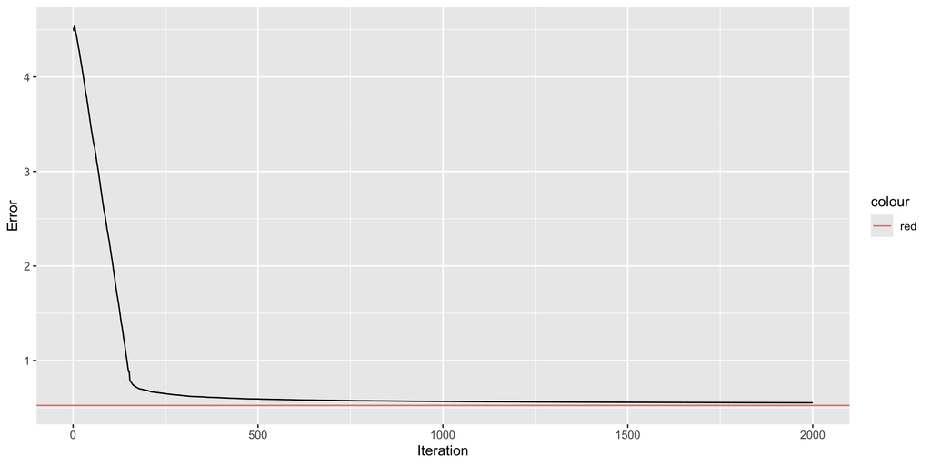

## PCA and Oja’s rule

Consider a linear neuron with output $z=\boldsymbol w^T \boldsymbol x$ that returns a linear combination of its inputs $\boldsymbol x$ using presynaptic weights $\boldsymbol w$.

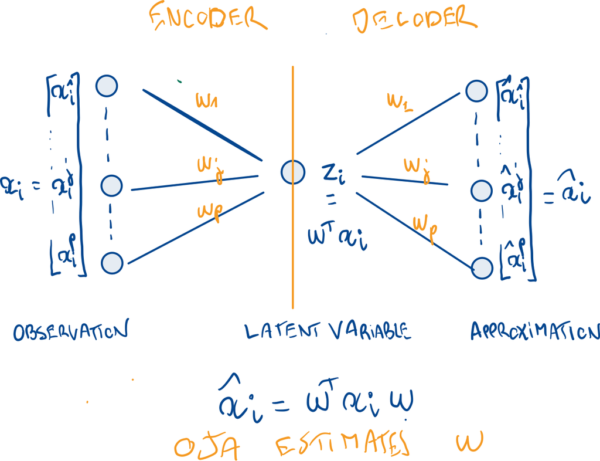

PCA according OJA

## Stochastic Gradient PCA and Oja’s rule

The criterion to be optimized can be written as

$$Q(\boldsymbol w) = \frac{1}{2n} \sum_i \|\boldsymbol x_i - \hat{\boldsymbol x_i}\|^2 = \frac{1}{2n} \sum_i \|\boldsymbol x_i - y_i \boldsymbol w \|^2=\frac{1}{2n} \sum_i \|\boldsymbol x_i - \boldsymbol w^T \boldsymbol x_i \boldsymbol w\|^2$$
where $\| \boldsymbol w\|^2=1$.

## Oja’s rule implementation

```r
Oja.rule<-function(X,max.iteration=10000,eta=0.001){
  p<-ncol(X);  n<-nrow(X)
  w<-rbind(rep(1,p)); w<-w/(sqrt(sum(w^2)))
  Q<-rep(0,max.iteration)
  for (i in 1:max.iteration){
    Q[i]<- 1/(2*n) *sum((X - X%*%t(w)%*%w)^2)
    x<-X[(i-1)%%n + 1,]
    y<-sum(w*x)
    w<-w + eta*y*(x-w*y)}
  return(list(w=w,Q=Q))
}
```

## Oja’s rule example with Fisher iris

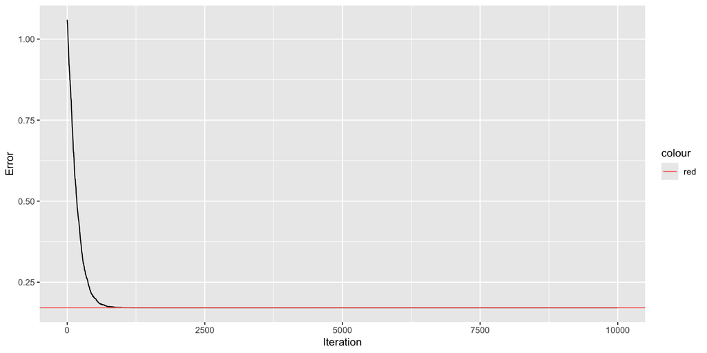

# Variational auto-encoder

## Variational autoencoder ideas

### The original papers

- Rezende, D. J., Mohamed, S., & Wierstra, D. (2014, June). Stochastic backpropagation and approximate inference in deep generative models. In International conference on machine learning (pp. 1278-1286). PMLR.
- Kingma, D. P., & Welling, M. (2013). Auto-encoding variational bayes. arXiv preprint arXiv:1312.6114.

### Main reference

- Diederik P. Kingma and Max Welling (2019), “An Introduction to Variational Autoencoders”, Foundations and Trends R in Machine Learning:

### What is does

- generate realistic samples of data,
- allow for accurate imputations of missing data,
- high-dimensional data visualisation
- Clustering

### How it works

**Latent variables** models which marry ideas from

- approximate Bayesian inference
  - ELBO (Evidence Lower BOund)
  - Reparametrization
- deep neural networks
  - Stochastic Gradient Descent
  - Retropropagation of the Gradient

to represent an approximate posterior distribution through variational lower bound optimization

## What is a VAE ?

### Coupling of 2 **parametric models**

VAE is a latent variable vector $\boldsymbol z$ and an observation $\boldsymbol x \in \mathbb R^D$
$$p(\boldsymbol x) = \int p(\boldsymbol x , \boldsymbol z)d\boldsymbol z$$

- encoder $g$ (recognition model): $p(\boldsymbol z| \boldsymbol x)$, which is approximated by $q_\Phi(\boldsymbol z| \boldsymbol x)$
- decoder $h\approx g^{-1}$ (generative model): $p_\Theta(\boldsymbol x| \boldsymbol z)$
- encoder and decoder could be neural networks

### Optimization of ELBO via Stochastic Gradient Ascent

- The VAE ELBO approximates the likelihood of a **latent variable** model
- The Gradient computation uses the re-parametrization trick
- Each step of the gradient ascent augment the ELBO as an **EM iteration**

## Example of use

### Data

Left batch of original training set - right : random generation of images

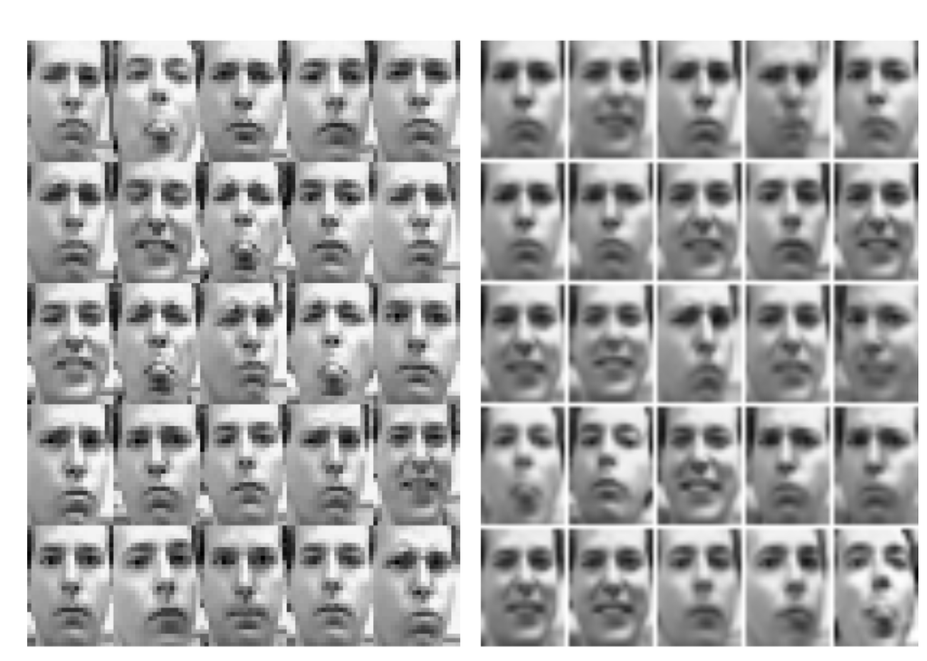

## Example of use

### Learning from data

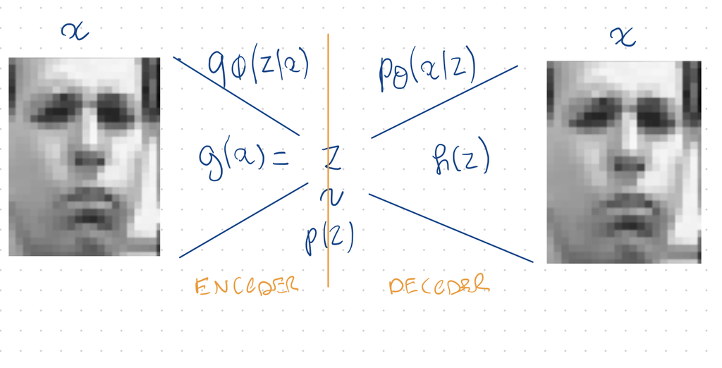

Frey image learning

## Example of use

### New Data generation from latent simulation

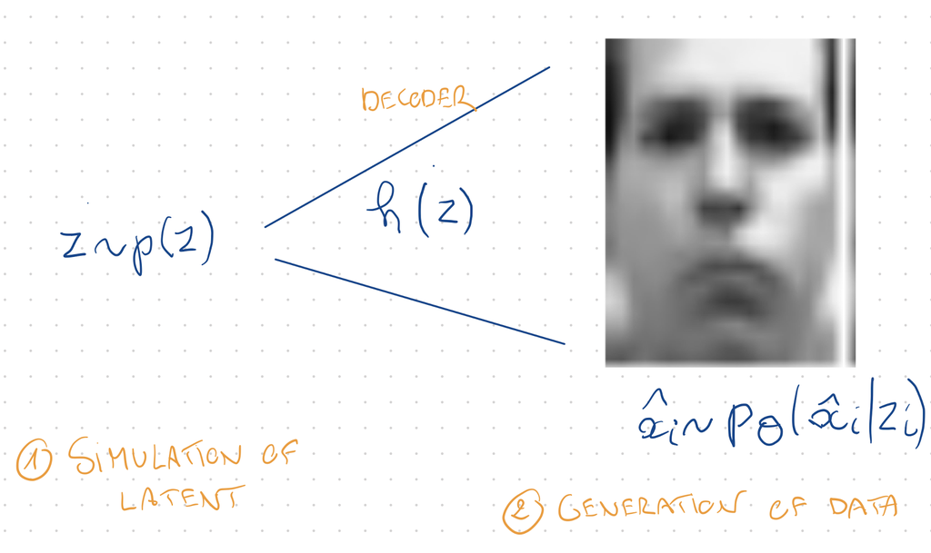

Frey image generation

## Example of use

### Data representation in latent space

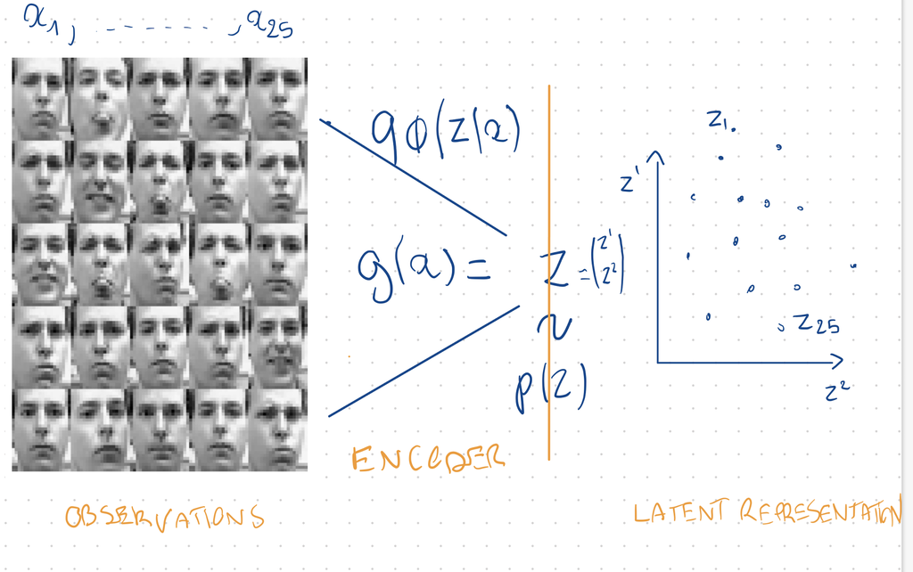

Frey image representation

## Example of use

### Missing data imputation after learning

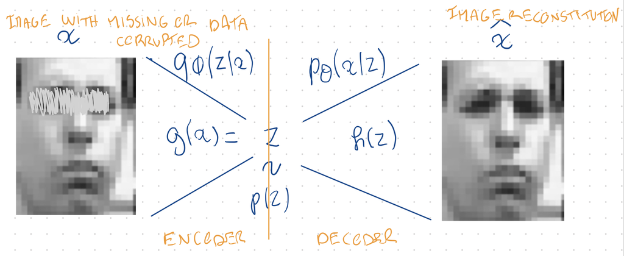

Frey image pixel imputation

## Ingredient: Parameterization of conditional distributions with Neural Networks

## Modeling joint distribution

- $\boldsymbol x$: Observed random variables
- $p^*(\boldsymbol x)$ : underlying unknown distribution
- $p_\theta(\boldsymbol x)$: model distribution
- Goal: $p_\theta(\boldsymbol x) \approx p^*(\boldsymbol x)$

We wish flexible $p_\theta(\boldsymbol x)$

## Modeling Conditional distribution

### Classification and regression

$$p_\theta (y | \boldsymbol x) \approx p^*(y | \boldsymbol x)$$

## Parameterization of conditional distributions with Neural Networks

### Classification

$$\theta = NeuralNet(\boldsymbol x)$$

$$p_\theta (y | \boldsymbol x) = Categorical(y,\theta)$$

## Ingredient: Stochastic Gradient

## What differences between Oja’s rule and VAE

### What is a VAE ?

Coupling of 2 **parametric models**

- decoder (generative model): $\boldsymbol x=h_\Theta(\boldsymbol z)$ where $p_\Theta(\boldsymbol x| \boldsymbol z)$
- encoder (recognition model): $\boldsymbol z=g_\Phi(\boldsymbol x)$ where $p(\boldsymbol z| \boldsymbol x)$ is approximated by $q_\Phi(\boldsymbol z| \boldsymbol x)$

### In Oja’s rule

- There are No probabilistic models
  - $z=g(\boldsymbol x)=\boldsymbol w^T \boldsymbol x$ and
  - $\hat{\boldsymbol x} = h(z)=z \boldsymbol w$,
- Encoder and decoder share the same parameters $w=\Theta=\Phi$

## Factor analysis generalizes Oja and is closer to a VAE

Factor analysis considers the observation $\boldsymbol x \in \mathbb R^D$
$$\boldsymbol x = \boldsymbol W \boldsymbol z + \boldsymbol \mu + \epsilon$$
where

- the noise $\epsilon \sim \mathcal N_D (\boldsymbol 0, \boldsymbol \Psi)$
- the hidden (latent) vector $\boldsymbol z \sim \mathcal N_L (\boldsymbol 0, \boldsymbol I_L)$

$$p(\boldsymbol x | \boldsymbol z, \theta) = \mathcal N (\boldsymbol x ; \boldsymbol W \boldsymbol z + \boldsymbol \mu, \boldsymbol \Psi)$$
the mean is a linear function of the (hidden) inputs

- $\boldsymbol W$ is a $D\times L$ matrix, known as the factor loading matrix,
- $\boldsymbol \Psi$ is a $D\times D$ covariance matrix that we take to be diagonal

The special case in which $\boldsymbol \Psi=\sigma^2 I$ is called probabilistic principal components analysis or PPCA.

## Ingredient : Evidence Lower BOund Minimization

## Missing data

In a missing data framework the log-likelihood of the parameters is advantageously expressed as
$$log P_\Theta( \boldsymbol x) = \mathbb E_{\boldsymbol z | \boldsymbol x}\left[ log \frac{P(\boldsymbol x,\boldsymbol z)}{P(\boldsymbol z | \boldsymbol x)}\right]$$

### Approximation

When the distribution of $\boldsymbol z|\boldsymbol x$ is intractable, an **approximation** $q_\Phi(\boldsymbol z|\boldsymbol x)$ is used

$q_\Phi(\boldsymbol z|\boldsymbol x)$ is the inverse function for $p_\Theta(\boldsymbol x|\boldsymbol z)$ in a **Bayes sense**

## ELBO

$$\begin{eqnarray*}
log P_\Theta( \boldsymbol x) &= & \mathbb E_{q_\Phi(\boldsymbol z | \boldsymbol x)}\left[ log \frac{P_\Theta(\boldsymbol x,\boldsymbol z)}{P_\Theta(\boldsymbol z | \boldsymbol x)}\right]\\
&=& \mathbb E_{q_\Phi(\boldsymbol z | \boldsymbol x)}\left[ log \frac{P_\Theta (\boldsymbol x,\boldsymbol z) q_\Phi(\boldsymbol z | \boldsymbol x)}{P_\Theta (\boldsymbol z | \boldsymbol x)q_\Phi(\boldsymbol z | \boldsymbol x)}\right]\\
&= & \underbrace{\mathbb E_{q_\Phi(\boldsymbol z | \boldsymbol x)}\left[ log \frac{P_\Theta(\boldsymbol x,\boldsymbol z) }{q_\Phi(\boldsymbol z | \boldsymbol x)}\right]}_{ELBO} + \underbrace{\mathbb E_{q_\Phi(\boldsymbol z | \boldsymbol x)}\left[ log \frac{q_\Phi(\boldsymbol z|\boldsymbol x) }{p_\Theta(\boldsymbol z | \boldsymbol x)}\right]}_{D_{KL}(q_\Phi(\boldsymbol z|\boldsymbol x)| p_\Theta(\boldsymbol z|\boldsymbol x))}
\end{eqnarray*}$$

where $D_{KL}(q_\Phi(\boldsymbol z|\boldsymbol x)| p_\Theta(\boldsymbol z|\boldsymbol x)) = -\mathbb E_q[\log{\frac{p}{q}}]\geq -\log \mathbb E_q[{\frac{p}{q}}]\geq 0$ from Jensen

## Two for one

- VAE finds parameters which approximately maximize the marginal likelihood $P_\Theta(\boldsymbol x)$ (good generative function)
- VAE finds the approximation of the recognition model which minimizes the KL divergence

## Alternative formulation of ELBO

ELBO can be rewritten as

$$ELBO = E_{q_\Phi(\boldsymbol z | \boldsymbol x)}\left[ log P_\Theta(\boldsymbol x|\boldsymbol z)\right]- D_{KL}(q_\Phi(\boldsymbol z|\boldsymbol x)| p_\Theta(\boldsymbol z))$$
For a suited choice of $p(\boldsymbol z)$ and $q(\boldsymbol z| \boldsymbol x)$, $D_{KL}(q_\Phi(\boldsymbol z|\boldsymbol x)| p_\Theta(\boldsymbol z))$ can be calculated in closed form.

### Exercices

1. Show that the ELBO can be rewritten as above
2. Compute the KL divergence between two multivariate Gaussians

## The ELBO is maximized by Stochastic Gradient

Let $\boldsymbol X$ be a i.i.d sample of random vector $\boldsymbol x$

$$ELBO(\boldsymbol X) = \sum_{\boldsymbol x \in \boldsymbol X} \mathcal{L}(\Theta, \Phi;\boldsymbol x)$$

### Gradient

The Gradient can be separated into 2 parts

1. $\nabla_\Theta \mathcal{L}(\Theta, \Phi;\boldsymbol x)$
2. $\nabla_\Phi \mathcal{L}(\Theta, \Phi;\boldsymbol x)$

## Decoder Gradient: $\nabla_\Theta \mathcal{L}(\Theta, \Phi;\boldsymbol x)$

Given some usually verified conditions and a Monte Carlo Approximation

$$\begin{eqnarray*}
\nabla_\Theta \mathcal{L}(\Theta, \Phi;\boldsymbol x)&=&
\nabla_\Theta \mathbb E_{q_\Phi(\boldsymbol z | \boldsymbol x)}\left[ log \frac{P_\Theta(\boldsymbol x,\boldsymbol z) }{q_\Phi(\boldsymbol z | \boldsymbol x)}\right] \\
&=&
\nabla_\Theta \mathbb E_{q_\Phi(\boldsymbol z | \boldsymbol x)}\left[ \log P_\Theta(\boldsymbol x,\boldsymbol z)\right]\\
&=&
\mathbb E_{q_\Phi(\boldsymbol z | \boldsymbol x)}\left[ \nabla_\Theta \log P_\Theta(\boldsymbol x,\boldsymbol z)\right]\\
&\approx& \nabla_\Theta \log P_\Theta(\boldsymbol x,\boldsymbol z)
\end{eqnarray*}$$

## Encoder Gradient: $\nabla_\Phi \mathcal{L}(\Theta, \Phi;\boldsymbol x)$

Encoder Gradient is more difficult to compute since in general
$$\begin{eqnarray*}
\nabla_\Phi \mathcal{L}(\Theta, \Phi;\boldsymbol x)&=&
\nabla_\Phi \mathbb E_{q_\Phi(\boldsymbol z | \boldsymbol x)}\left[ log \frac{P_\Theta(\boldsymbol x,\boldsymbol z) }{q_\Phi(\boldsymbol z | \boldsymbol x)}\right] \\
&=&
\nabla_\Phi \mathbb E_{q_\Phi(\boldsymbol z | \boldsymbol x)}\left[ \log P_\Theta(\boldsymbol x,\boldsymbol z) - \log q_\Phi(\boldsymbol z|\boldsymbol x)\right]\\
&\neq&
\mathbb E_{ q_\Phi(\boldsymbol z | \boldsymbol x)}\left[ \nabla_\Phi \log P_\Theta(\boldsymbol x,\boldsymbol z) - \nabla_\Phi \log q_\Phi(\boldsymbol z|\boldsymbol x)\right]
\end{eqnarray*}$$

A reparametrization (variable change) trick allows a workaround

## Encoder function

Let us rewrite the decoder function with a random vector $\boldsymbol \epsilon$ whose distribution is not parametrized by $\Phi$:

$$\boldsymbol z = g(\boldsymbol x, \boldsymbol \epsilon ; \Phi)$$

$$\begin{eqnarray*}
\nabla_\Phi \mathcal{L}(\Theta, \Phi;\boldsymbol x)&=&
\nabla_\Phi \mathbb E_{p(\boldsymbol \epsilon)}\left[ log \frac{P_\Theta(\boldsymbol x,\boldsymbol z) }{q_\Phi(\boldsymbol z | \boldsymbol x)}\right] \\
&=&
\nabla_\Phi \mathbb E_{p(\boldsymbol \epsilon )}\left[ \log P_\Theta(\boldsymbol x,\boldsymbol z) - \log q_\Phi(\boldsymbol z|\boldsymbol x)\right]\\
&=&
\mathbb E_{p(\boldsymbol \epsilon )} \left[ \nabla_\Phi \log P_\Theta(\boldsymbol x,\boldsymbol z) - \nabla_\Phi \log q_\Phi(\boldsymbol z|\boldsymbol x)\right]\\
&\approx& \nabla_\Phi \log P_\Theta(\boldsymbol x,\boldsymbol z) - \nabla_\Phi \log q_\Phi(\boldsymbol z|\boldsymbol x)
\end{eqnarray*}$$

We just have to compute $\log q_\Phi(\boldsymbol z|\boldsymbol x)$ after the change of variable

## Reparametrization trick

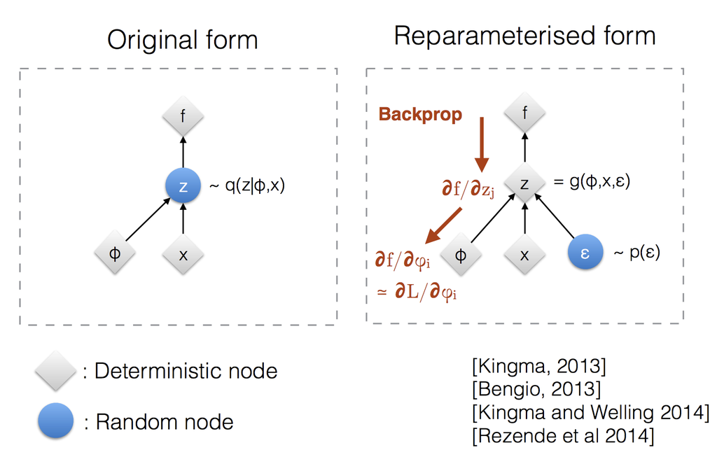

## Computing $\log q_\Phi(\boldsymbol z|\boldsymbol x)$ with a change of variable

$$\log q_\Phi(\boldsymbol z|\boldsymbol x) = \log p(\boldsymbol \epsilon) - \log d_\Phi(\boldsymbol x, \boldsymbol \epsilon)$$
where the second term is the log of the absolute value of the determinant of the Jacobian matrix:

$$\log d_\Phi(\boldsymbol x, \boldsymbol \epsilon) = \log
\left|
\det
\begin{pmatrix}
\frac{\partial z_1}{\partial \epsilon_1} & \cdots & \frac{\partial z_1}{\partial \epsilon_k}\\
\vdots & \ddots & \vdots \\
\frac{\partial z_k}{\partial \epsilon_1} & \cdots & \frac{\partial z_k}{\partial \epsilon_k}\\
\end{pmatrix}
\right|$$

variable change $g()$ is chosen for the logdet being computationally affordable/simple

## Factorized Gaussian Posterior

### Model

$$(\boldsymbol \mu, \log \boldsymbol \sigma) = EncoderNN_\Phi(\boldsymbol x)$$

$$q_\Phi (\boldsymbol z | \boldsymbol x) = \mathcal N(\boldsymbol z ; \boldsymbol \mu, diag(\boldsymbol \sigma^2) )$$
$$q_\Phi (\boldsymbol z | \boldsymbol x)=\prod_i q_\Phi(z_i | \boldsymbol x) = \prod_i \mathcal N(z_i | EncoderNN_\Phi(\boldsymbol x)) = \prod_i \mathcal N(z_i | \mu_i, \sigma^2_i)$$

### Reparametrization

$$\boldsymbol \epsilon \sim \mathcal N(\boldsymbol 0, \boldsymbol I)$$

$$\boldsymbol z = \boldsymbol \mu+ \boldsymbol \sigma \odot \boldsymbol \epsilon$$

## Factorized Gaussian Posterior

The Jacobian of the transformation is
$$\log d_\Phi(\boldsymbol x, \boldsymbol \epsilon) = \log
\left|
\det
\begin{pmatrix}
\frac{\partial z_1}{\partial \epsilon_1} & \cdots & \frac{\partial z_1}{\partial \epsilon_k}\\
\vdots & \ddots & \vdots \\
\frac{\partial z_k}{\partial \epsilon_1} & \cdots & \frac{\partial z_k}{\partial \epsilon_k}\\
\end{pmatrix}
\right| = \log \prod_i \sigma_i$$

The log posterior density is

$$\begin{eqnarray*}
\log q_\Phi (\boldsymbol z | \boldsymbol x) &=& \log p(\boldsymbol \epsilon) - \log |det(\frac{\partial \boldsymbol z}{\partial \boldsymbol \epsilon})|\\
&=& \sum_i \log \mathcal N(\epsilon_i ;0,1) - \log \sigma_i
\end{eqnarray*}$$

## Reparametrization trick

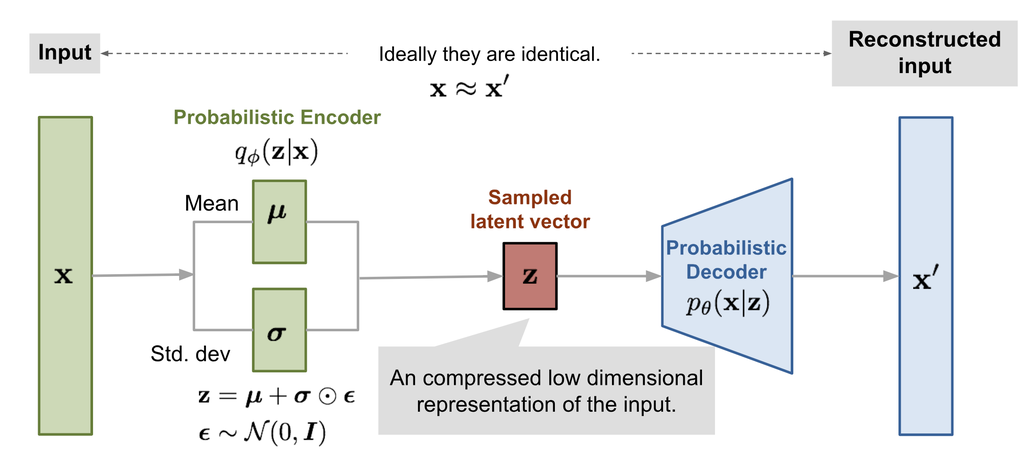

## Full Gaussian posterior

### Model

$$q_\Phi (\boldsymbol z | \boldsymbol x) = \mathcal N(\boldsymbol z ; \boldsymbol \mu, \boldsymbol \Sigma )$$

### Reparametrization

$$\boldsymbol \epsilon \sim \mathcal N(\boldsymbol 0, \boldsymbol I)$$

$$\boldsymbol z = \boldsymbol \mu+ \boldsymbol L \boldsymbol \epsilon$$
Where $\boldsymbol L$ is a lower triangular matrix obtained from a Cholesky decompostion of $\boldsymbol \Sigma = \boldsymbol L \boldsymbol L^T$

## Full Gaussian posterior

The Jacobian has a simple form

$$\frac{\partial \boldsymbol z}{\partial \boldsymbol \epsilon} = \boldsymbol L$$

As the determinant of a triangular matrix is the product of its diagonal terms,

$$\begin{eqnarray*}
\log q_\Phi (\boldsymbol z | \boldsymbol x) &=& \log p(\boldsymbol \epsilon) - \log |det(\frac{\partial \boldsymbol z}{\partial \boldsymbol \epsilon})|\\
&=& \sum_i \log \mathcal N(\epsilon_i ;0,1) - \log L_{ii}
\end{eqnarray*}$$

## Algorithm input and output

Input:

- $\boldsymbol X$: Dataset
- $h(\boldsymbol z)$ decoding function, with dist. $p_\Theta(\boldsymbol x, \boldsymbol z)$
- $g(\boldsymbol x)$ encoding function with dist. $q_\Psi(\boldsymbol z | \boldsymbol x)$

Output:

- $\Theta$
- $\Phi$

## Algorithm

Initialisation of $\Theta$ and $\Phi$

While SGD not converged do

- Draw a random minibatch $\boldsymbol X^M \in \boldsymbol X$
- $\boldsymbol \epsilon \sim p(\boldsymbol \epsilon)$ (Random noise for every datapoint in $\boldsymbol X^M$)
- Compute
  - $\tilde{\mathcal L}_{\Theta, \Phi}(\boldsymbol X^M, \boldsymbol \epsilon)=\frac{1}{m}\sum_{\boldsymbol x \in \boldsymbol X^M} \left({\log p_\Theta(\boldsymbol x, \boldsymbol z) - \underbrace{\log q_\Phi(\boldsymbol z|\boldsymbol x)}_{\log p(\epsilon) -\log d_\Phi(\boldsymbol x,\boldsymbol \epsilon)}} \right)$ and
  - its gradients
    - $\nabla_\Theta \tilde{\mathcal L}_{\Theta, \Phi}(\boldsymbol X^M, \boldsymbol \epsilon) = \frac{1}{m}\sum_{\boldsymbol x \in \boldsymbol X^M} \frac{\partial \log p_\Theta(\boldsymbol x, \boldsymbol z)}{\partial \Theta}$
    - $\nabla_\Phi \tilde{\mathcal L}_{\Theta, \Psi}(\boldsymbol X^M, \boldsymbol \epsilon) = \frac{1}{m}\sum_{\boldsymbol x \in \boldsymbol X^M} \frac{\log \partial d_\Phi(\boldsymbol x, \boldsymbol \epsilon)}{\partial \Phi}$
- $\begin{pmatrix}\Theta \\ \Phi\end{pmatrix} := \begin{pmatrix}\Theta \\ \Phi\end{pmatrix} + \eta \begin{pmatrix}\nabla_\Theta \tilde{\mathcal L}_{\Theta, \Phi}(\boldsymbol X^M, \boldsymbol \epsilon) \\ \nabla_\Phi \tilde{\mathcal L}_{\Theta, \Phi}(\boldsymbol X^M, \boldsymbol \epsilon) \end{pmatrix}$

## Original example from Kingma: Gaussian model with MLP parametrization

### Multivariate Gaussian decoder with a diagonal covariance structure

Decoder $p_\Theta(\boldsymbol x| \boldsymbol z)$ or decoder (just swap $\boldsymbol x$ and $\boldsymbol z$) are assumed to have multivariate Gaussian dist. with a diagonal covariance structure:

### Decoder

- $log p(x|z) = \log \mathcal N (\boldsymbol x; \boldsymbol \mu, \sigma^2 I)$ where $\boldsymbol \mu = W_4 \boldsymbol h+b_4$
- $\log\sigma^2 =W_5 \boldsymbol h+b_5$
- $\boldsymbol h = \tanh (W_3\boldsymbol z + b_3)$

where $\{W_3, W_4, W_5, b_3, b_4, b_5\}$ are the weights and biases of the MLP and part of $\Theta$ when used as decoder.

### Encoder

- Let us consider the prior $p_\Theta(\boldsymbol z) = \mathcal N(0,I)$
- swap $\boldsymbol x$ and $\boldsymbol z$ in the decoder above to get $q_\Phi(\boldsymbol z| \boldsymbol x)$

## Gaussian VAE illustrated

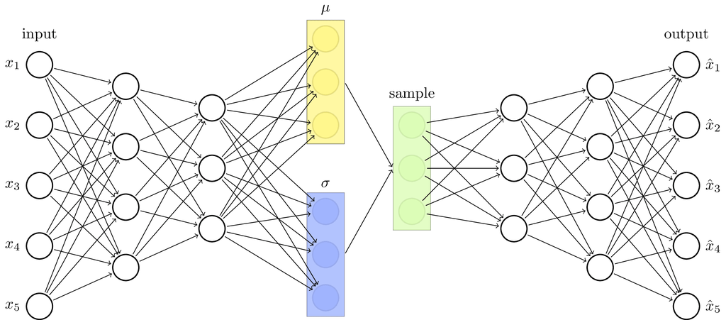

# Mixture of Experts

## Historical Context

- Introduced in the early 1990s by Jacobs et al. (1991).

### Ideas and Intuitions

- **Inspired by cognitive science**, mimicking expert decision-making by assigning specialized sub-models to different tasks.
- **Enhances generalization** by combining multiple specialized models rather than relying on a single monolithic structure.
- **Divide-and-conquer approach** enables decomposition of complex tasks into manageable subtasks, improving prediction accuracy (Masoudnia & Ebrahimpour, 2014; Yuksel et al., 2012).
- **Widely applied in machine learning**, including speech recognition, image processing, LLM (Deepseek, Mixtral, ChatGPT…)

## MoE Components

- **Experts**: Independent models (e.g., neural networks, regressions) specialized in subsets of data.
- **Gating Network**: Evaluates input data and assigns relevance weights to experts.
- Combines expert outputs into a final prediction (Gormley & Eisner, 2019).

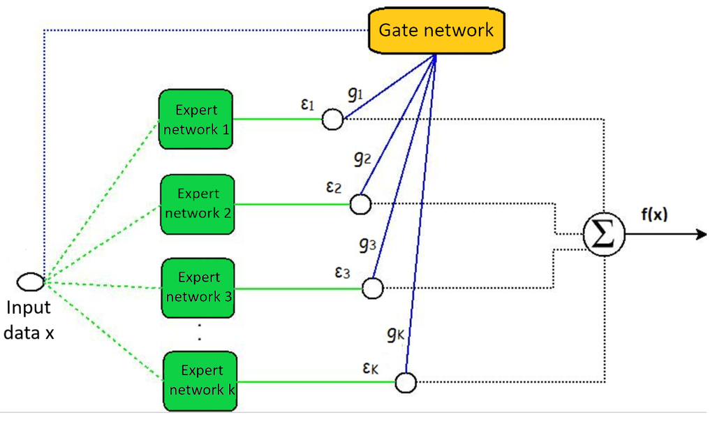

## Model Formulation

$$f(y_i; \boldsymbol x_i, \boldsymbol \Theta)= \sum_{k=1}^K g_k(\boldsymbol x_i; \boldsymbol \alpha_k) f_k(y_i ; \boldsymbol x_i, \boldsymbol \beta_k)$$

- $g_k(\boldsymbol x_i)$: Output of the gating network

### Probabilistic formulation

- $f(y_i; \boldsymbol x_i, \boldsymbol \Theta)= p(y_i | \boldsymbol x_i,\boldsymbol \Theta)$
- the gating network comes from a latent variable $z$:
  $$g_k(\boldsymbol x_i )= p(z_i=k \mid \boldsymbol x_i)$$
  where
  $$z_i=k \mid \boldsymbol x_i \sim M\left(1; g(\boldsymbol x_i)=(g_1(\boldsymbol x_i), \dots, g_K(\boldsymbol x_i))\right)$$
- $g$ is a sigmoid function for $K=2$ or softmax for $K>2$.
- The expert $f_k(y_i ; \boldsymbol x_i, \boldsymbol \beta_k)$ models a pdf corresponding the nature of $y_i$

## MoE Architectures

- Different types of expert models (Gormley & Eisner, 2019).
- Variants include mixture models (unsupervised), prediction models (supervised).

### Advantages & Challenges

- MoEs enable large-scale models while reducing computational costs.
- Challenges: high parameter count, complex gating network training.

## Example of regression mixture

### Training Process

- **Labeled Data:**
  - The MoE is trained on a dataset where each input is associated with a known output.
- **Expert Specialization:**
  - Each expert learns to master a specific subset of the data, allowing for finer modeling of variations present in the data.
- **Gating Network Training:**
  - The gating network learns to associate inputs with the appropriate experts based on data characteristics.

### Inference Phase

- **Input Routing:**
  - For new data, the gating network evaluates its characteristics and selects the most suitable expert to make the prediction.
- **Output Combination:**
  - In some cases, outputs from multiple experts may be combined to obtain a more robust final prediction.

## Example of regression mixture

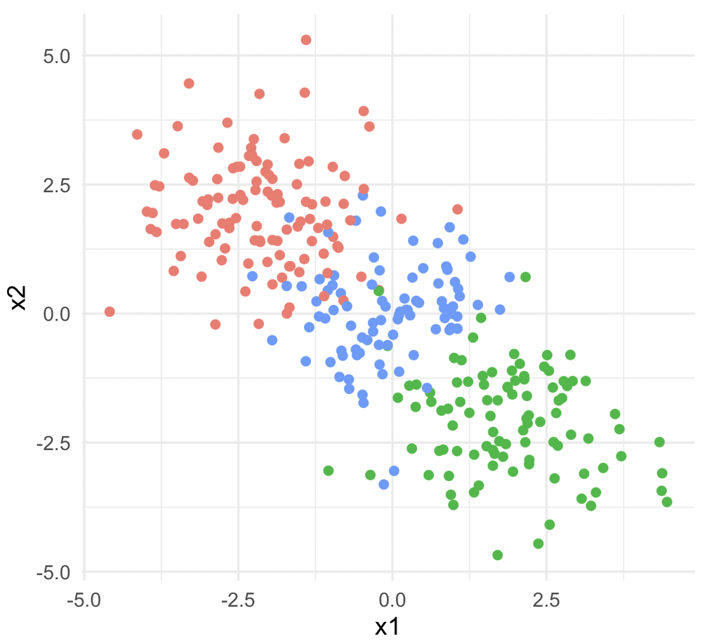

## Example of regression mixture

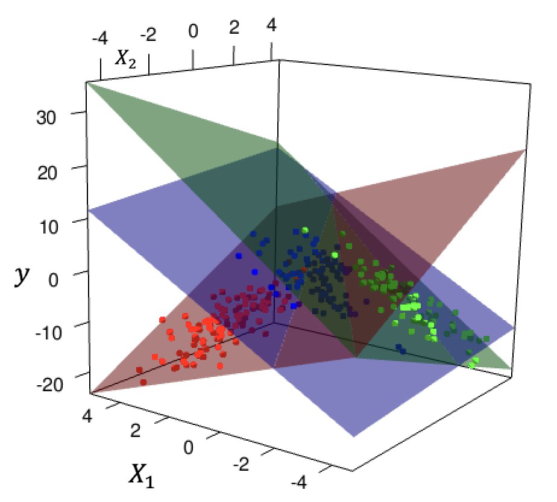

## Example of regression mixture

We can model this by allowing the mixing weights and the mixture densities to be input-dependent:

$$p(y_i \mid x_i, z_i = k, \beta_k,\sigma_k) = \mathcal{N}(y_i \mid \mathbf{\beta}_k^\top x_i, \sigma_k^2 I_2)$$

$$p(z_i \mid x_i, \theta) = \text{Cat}(z_i \mid g(\mathbf{\alpha}^\top x_i))$$

# Singular Value Decomposition

## Singular Value Decomposition

### Eigendecomposition of symmetric matrices

$\forall \boldsymbol A \in \mathbb R^{n\times n}$, there exist an orthonormal matrix $\boldsymbol Q \in R^{n\times n}$ and a diagonal matrix $\boldsymbol \Lambda = diag(\lambda_1, \cdots, \lambda_n)$

$$A=\boldsymbol Q \boldsymbol\Lambda \boldsymbol Q^T$$

### Singular Value Decomposition

Extend the decomposition to **rectangular matrices**

$$\boldsymbol X = \boldsymbol{USV^T}$$

## Applications in machine learning

- **Dimensionality Reduction**: SVD can be used for dimensionality reduction by reducing the rank of a matrix
- **Latent Semantic Analysis**: By decomposing a term-document matrix using SVD, LSA can capture the latent semantic structure of the data
- **Principal Component Analysis (PCA)**: PCA is a SVD
- **Recommender Systems**: By factorizing the matrix using SVD, we can identify latent factors or features that capture underlying patterns and preferences.
- **Image Compression**: SVD is used in image compression techniques such as JPEG.
- **Matrix Completion**: SVD-based techniques are used in matrix completion problems, where missing or incomplete data needs to be imputed.
- …

## Existence of the SVD for general matrices

For any matrix $\boldsymbol X \in \mathbb R^{n\times d}$, there exist two orthogonal matrices $\boldsymbol U \in \mathbb R^{n\times n}$, $\boldsymbol V \in \mathbb R^{d\times d}$ and a nonnegative, ‘’diagonal’’ matrix $\boldsymbol S \in \mathbb R^{n\times d}$ such that

$$\boldsymbol X_{n\times d} =\boldsymbol U_{n\times n} \boldsymbol S_{n\times d}\boldsymbol V_{d\times d}^T$$

where $\boldsymbol U^T \boldsymbol U=\boldsymbol I$ and $\boldsymbol V^T \boldsymbol V=\boldsymbol I$.

### In a vector form

$$\boldsymbol X_{n\times d} = \sum_{j=1}^r S_{jj} \boldsymbol u_j \boldsymbol v_j^T$$
where $r=rank(\boldsymbol X)$.

## Geometrical interpretation

Given any matrix $\boldsymbol X \in \mathbb R^{n\times d}$ it defines a linear transformation:

$$f : \mathbb R^d \rightarrow \mathbb R^n, f(\boldsymbol x) = \boldsymbol X \boldsymbol x.$$
The linear transformation $f$ can be decomposed into three operations:

$$\underbrace{\boldsymbol X}_{linear \ transformation} \boldsymbol x =
\underbrace{\boldsymbol U}_{rotation} \underbrace{ \boldsymbol S}_{scaling} \underbrace{\boldsymbol V^T}_{rotation} {\boldsymbol x}$$

## Geometrical interpretation

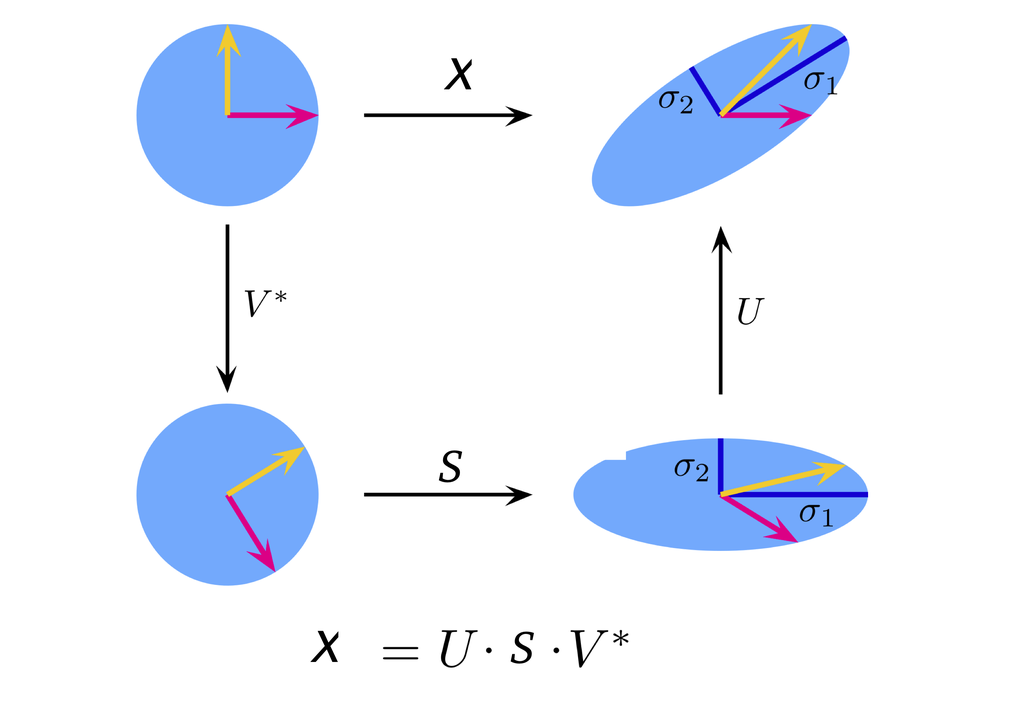

## Different versions of SVD

- Full SVD:

$$X_{n\times d} =\boldsymbol U_{n\times n} \boldsymbol S_{n\times d}\boldsymbol V_{d\times d}^T$$
- Economy sized (thin, compact) SVD:

$$X_{n\times d} =\boldsymbol U_{n\times r} \boldsymbol S_{r\times r}\boldsymbol V_{r\times d}^T$$